# The Intrinsic Conditional Auto-Regressive (ICAR) Model in Stan

### ICAR Model Specification

- Conditional specification: multivariate normal random vector $\mathbf{\phi}$ where each ${\phi}_i$ is conditional on the values of its neighbors
- Joint specification rewrites to *Pairwise Difference*,
  $$p(\phi) \propto \exp \left\{ {- \frac{1}{2}} \sum_{i \sim j}{({\phi}_i - {\phi}_j)}^2 \right\}$$
- Each ${({\phi}_i - {\phi}_j)}^2$ contributes a penalty term based on the distance between the values of neighboring regions
- $\phi$ is non-identifiable, constant added to $\phi$ washes out of ${\phi}_i - {\phi}_j$
  - A sum-to-zero constraint identifies and centers $\phi$

### Stan implementation

Encode neighbor information as graph edgeset, i.e. pairs of indices for neighbors $i, j$:

```stan
data {
  int<lower = 0> N;  // number of areal regions
  int<lower = 0> N_edges;  // number of neighbor pairs
  array[2, N_edges] int<lower = 1, upper = N> neighbors; // column-wise adjacent
  ...
```

Use Stan’s `sum_to_zero_vector` to identify `phi`

```stan
parameters {
  sum_to_zero_vector[N] phi; // spatial random effects
  ...
```

Use Stan’s vectorized operations to compute log probability density

```stan
model {
  target += -0.5 * dot_self(phi[node1] - phi[node2]);
  ...
```

## Notebook Setup

Import all libraries, load the NYC study data.

**Python**

```python
# import all libraries used in this notebook
import os
import numpy as np
import pandas as pd
import geopandas as gpd
import libpysal
import matplotlib
from splot.libpysal import plot_spatial_weights
import plotnine as p9
%matplotlib inline

from cmdstanpy import CmdStanModel, cmdstan_path, cmdstan_version

import warnings
warnings.filterwarnings('ignore')
from utils_bym2 import get_scaling_factor, nbs_to_adjlist
from utils_dataviz import *
```

```python
nyc_geodata = gpd.read_file(os.path.join('..', 'data', 'nyc_study.geojson'))
nyc_geodata.columns
```

```
Index(['CTLabel', 'BoroCode', 'BoroName', 'CT2010', 'BoroCT2010', 'CDEligibil',
       'NTACode', 'NTAName', 'PUMA', 'Shape_Leng', 'Shape_Area', 'BoroFips',
       'ct2010full', 'kids_per_sq_mi', 'count', 'kid_pop', 'pct_pubtransit',
       'med_hh_inc', 'traffic', 'frag_index', 'geometry'],
      dtype='object')
```

**R**

````markdown
```{r}
library(sf)
library(spdep) |> suppressPackageStartupMessages()
library(ggplot2)
library(tidyverse) |> suppressPackageStartupMessages()
library(cmdstanr)
library(posterior)
library(bayesplot)
library(loo)
library(parallel)
cores = floor(parallel::detectCores() / 2)
source("utils_bym2.R")
source("utils_dataviz.R")
options(width = 120)
```
````

````markdown
```{r}
nyc_geodata = st_read(file.path('..', 'data', 'nyc_study.geojson'))
names(nyc_geodata)
```
````

## New York City Neighbor Graph

New York city consists of several islands; only the Bronx is part of the mainland; Brooklyn and Queens are part of Long Island, Manhattan and Staten Island are large islands with hundreds of census tracts, and City Island, Roosevelt Island, and the Rockaways are smaller, comprised of 1, 2, and approximate 20 census tracts, respectively.

*This is a problem for the ICAR model, which operates on a fully connected graph (single component)*

**Python**

```python
w_nyc_nbs = libpysal.weights.Queen.from_dataframe(nyc_geodata, geom_col='geometry')
print(f'number of components: {w_nyc_nbs.n_components}')
print(f'islands? {w_nyc_nbs.islands}')
print(f'max number of neighbors per node: {w_nyc_nbs.max_neighbors}')
print(f'mean number of neighbors per node: {w_nyc_nbs.mean_neighbors}')
```

```
number of components: 8
islands? [328, 1860, 1903]
max number of neighbors per node: 14
mean number of neighbors per node: 5.891169451073986
```

**R**

````markdown
```{r}
nyc_nbs = poly2nb(nyc_geodata)
summary(nyc_nbs)
table(n.comp.nb(nyc_nbs)$comp.id)
```
````

**Python**

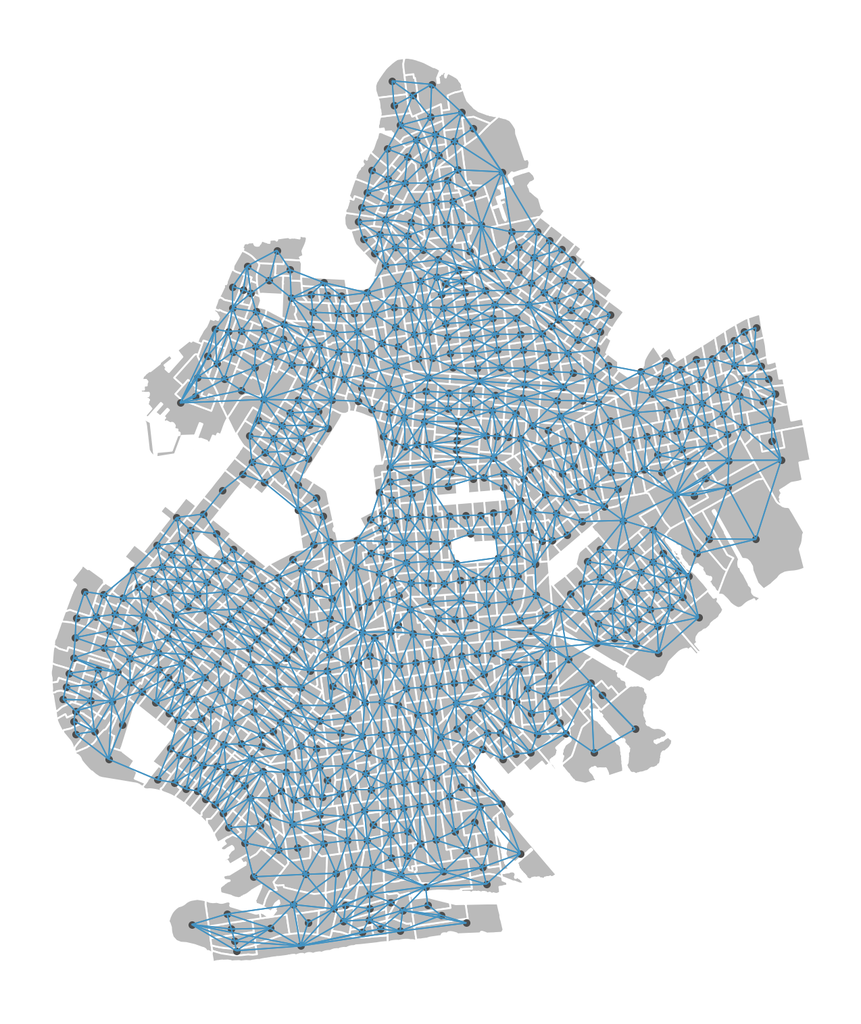

```python
brooklyn_geodata = nyc_geodata[nyc_geodata['BoroName']=='Brooklyn'].reset_index(drop=True)
brooklyn_nbs = libpysal.weights.Queen.from_dataframe(brooklyn_geodata, geom_col='geometry')
plot_spatial_weights(brooklyn_nbs, brooklyn_geodata)
```

```python
print(f'number of components: {brooklyn_nbs.n_components}')
print(f'islands? {brooklyn_nbs.islands}')
print(f'max number of neighbors per node: {brooklyn_nbs.max_neighbors}')
print(f'mean number of neighbors per node: {brooklyn_nbs.mean_neighbors}')
```

```
number of components: 1
islands? []
max number of neighbors per node: 13
mean number of neighbors per node: 6.029530201342282
```

**R**

````markdown
```{r}
brooklyn_geodata = nyc_geodata[nyc_geodata$BoroName=='Brooklyn', ]
brooklyn_nbs = poly2nb(brooklyn_geodata)
brooklyn_coords = st_coordinates(st_centroid(brooklyn_geodata['geometry']))
plot(st_geometry(brooklyn_geodata), col='skyblue')
plot(brooklyn_nbs, coords=brooklyn_coords, add=TRUE, pch=20, cex=0.6)
```
````

````markdown
```{r}
summary(brooklyn_nbs)
```
````

## ICAR Model: `poisson_icar.stan`

### Coding the neighbor graph

- $N \times N$ Adjacency matrix
  - Entries $(i,\ j)$ and $(j,\ i)$ are 1 when regions $n_i$ and $n_j$ are neighbors, 0 otherwise
- Undirected graph: regions are vertices, pairs of neighbors are edges
  - Encoded as *edges* - 2 column matrix, each row is a pair of neighbors $({n_i}, {n_j})$

The Stan ICAR model uses the latter. Encode neighbor information as a graph.

- Nodes are indexed from 1:N.
- Edges indices are stored in a 2 x N array
  - each column is an edge
  - row 1: index of first node in edge pair, $n_i$
  - row 2: index of second node in edge pair, $n_j$

```stan
  int<lower = 0> N;  // number of areal regions
  // spatial structure
  int<lower = 0> N_edges;  // number of neighbor pairs
  array[2, N_edges] int<lower = 1, upper = N> neighbors;  // node[1, j] adjacent to node[2, j]
```

### Coding the ICAR component

The joint distribution of the ICAR model is expressed as the *pairwise difference* between neighboring regions in the neighbor graph.

$$p(\phi) \propto \exp \left\{ {- \frac{1}{2}} \sum_{i \sim j}{({\phi}_i - {\phi}_j)}^2 \right\}$$

The joint distribution is non-identifiable; adding any constant to all of the elements of $\phi$ leaves it unchanged, therefore we add the constraint $\sum_{i} {\phi}_i = 0$.

- Use Stan’s constrained parameter type `sum_to_zero_vector` to identify the joint distribution.

```stan
  sum_to_zero_vector[N] phi; // spatial effects
```

- Use Stan’s vectorized operations to compute log probability density:

```stan
   target += -0.5 * dot_self(phi[node1] - phi[node2]);  // ICAR prior
```

### Putting it all together

This file is in directory `stan/poisson_icar.stan`.

**Python**

```python
poisson_icar_model_file = os.path.join('..', 'stan', 'poisson_icar.stan')

with open(poisson_icar_model_file, 'r') as file:
    contents = file.read()
    print(contents)
```

```
data {
  int<lower=0> N;
  array[N] int<lower=0> y; // count outcomes
  vector<lower=0>[N] E; // exposure
  int<lower=1> K; // num covariates
  matrix[N, K] xs; // design matrix

  // spatial structure
  int<lower = 0> N_edges;  // number of neighbor pairs
  array[2, N_edges] int<lower = 1, upper = N> neighbors;  // columnwise adjacent
}
transformed data {
  vector[N] log_E = log(E);
  // center continuous predictors
  vector[K] means_xs;  // column means of xs before centering
  matrix[N, K] xs_centered;  // centered version of xs
  for (k in 1:K) {
    means_xs[k] = mean(xs[, k]);
    xs_centered[, k] = xs[, k] - means_xs[k];
  }
}
parameters {
  real beta0; // intercept
  vector[K] betas; // covariates
  sum_to_zero_vector[N] phi; // spatial effects
  real<lower=0> sigma; // overall spatial variance
}
model {
  y ~ poisson_log(log_E + beta0 + xs_centered * betas + phi * sigma);
  beta0 ~ std_normal();
  betas ~ std_normal();
  sigma ~ std_normal();
  target += -0.5 * dot_self(phi[neighbors[1]] - phi[neighbors[2]]);  // ICAR prior
}
generated quantities {
  real beta_intercept = beta0 - dot_product(means_xs, betas);  // adjust intercept
  array[N] int y_rep;
  {
    vector[N] eta = log_E + beta0 + xs_centered * betas + phi * sigma;
    y_rep = max(eta) < 26 ? poisson_log_rng(eta) : rep_array(-1, N);
  }
}
```

**R**

````markdown
```{r}
poisson_icar_model_file = file.path('..', 'stan', 'poisson_icar.stan')
cat(readLines(poisson_icar_model_file), sep="\n")
```
````

## Data Prep

### Get edgeset

- Compute this automatically from `nyc_geodata` spatial geometry component
  - Python package `libpysal`
  - R package `spdep`

**Python**

```python
brooklyn_nbs_adj = nbs_to_adjlist(brooklyn_nbs)
brooklyn_nbs_adj
```

```
array([[  1,   1,   1, ..., 739, 740, 741],
       [  3,   4,   5, ..., 742, 742, 742]])
```

**R**

````markdown
```{r}
brooklyn_nbs_adj = nbs_to_adjlist(brooklyn_nbs)
brooklyn_nbs_adj[1:2, 1:10]
```
````

### Assemble the input data

**Python**

```python
design_vars = np.array(['pct_pubtransit','med_hh_inc', 'traffic', 'frag_index'])

design_mat = brooklyn_geodata[design_vars].to_numpy()
design_mat[:, 1] = np.log(design_mat[:, 1])
design_mat[:, 2] = np.log(design_mat[:, 2])

pd.DataFrame(data=design_mat).describe()
```

|  | 0 | 1 | 2 | 3 |
| --- | --- | --- | --- | --- |
| count | 745.000000 | 745.000000 | 745.000000 | 745.000000 |
| mean | 0.743001 | 10.786729 | 9.906006 | -0.216161 |
| std | 0.136709 | 0.435962 | 0.815884 | 2.008809 |
| min | 0.228300 | 9.362289 | 7.074117 | -5.696500 |
| 25% | 0.652600 | 10.537628 | 9.361945 | -1.593300 |
| 50% | 0.766100 | 10.768885 | 9.784310 | -0.193700 |
| 75% | 0.850200 | 11.096561 | 10.289056 | 1.150200 |
| max | 1.000000 | 12.226880 | 12.108487 | 6.688900 |

```python
pois_icar_data = {"N":brooklyn_geodata.shape[0],
             "y":brooklyn_geodata['count'].astype('int'),
             "E":brooklyn_geodata['kid_pop'].astype('int'),
             "K":4,
             "xs":design_mat,
             "N_edges": brooklyn_nbs_adj.shape[1],
             "neighbors": brooklyn_nbs_adj
}
```

**R**

````markdown
```{r}
design_mat <- as.data.frame(brooklyn_geodata) %>%
  select(pct_pubtransit, med_hh_inc, traffic, frag_index) %>%
  mutate(med_hh_inc = log(med_hh_inc),
         traffic = log(traffic))
summary(design_mat)
```
````

````markdown
```{r}
pois_icar_data <- list(
  N = nrow(brooklyn_geodata),
  y = as.integer(brooklyn_geodata$count),
  E = as.integer(brooklyn_geodata$kid_pop),
  K = 4,
  xs = design_mat,
  N_edges = ncol(brooklyn_nbs_adj),
  neighbors = brooklyn_nbs_adj
)
```
````

## Fitting the ICAR Model on the Brooklyn data

### Model is compiled (as needed) on instantiation

**Python**

```python
pois_icar_mod = CmdStanModel(stan_file=poisson_icar_model_file)
```

**R**

````markdown
```{r}
pois_icar_mod = cmdstan_model(stan_file=poisson_icar_model_file)
```
````

### Run the NUTS-HMC sampler, summarize results

**Python**

```python
pois_icar_fit = pois_icar_mod.sample(data=pois_icar_data)
pois_icar_fit.summary().round(2).loc[
  ['beta_intercept', 'beta0', 'betas[1]', 'betas[2]', 'betas[3]', 'betas[4]', 'sigma']]
```

```
09:40:36 - cmdstanpy - INFO - CmdStan start processing
```

```
09:40:40 - cmdstanpy - INFO - CmdStan done processing.
```

|  | Mean | MCSE | StdDev | MAD | 5% | 50% | 95% | ESS_bulk | ESS_tail | R_hat |
| --- | --- | --- | --- | --- | --- | --- | --- | --- | --- | --- |
| beta_intercept | -10.51 | 0.04 | 1.23 | 1.22 | -12.50 | -10.52 | -8.49 | 862.75 | 1331.18 | 1.0 |
| beta0 | -4.27 | 0.00 | 0.02 | 0.02 | -4.30 | -4.27 | -4.25 | 4922.93 | 3000.17 | 1.0 |
| betas[1] | 1.00 | 0.01 | 0.38 | 0.37 | 0.40 | 1.01 | 1.61 | 1007.85 | 1841.32 | 1.0 |
| betas[2] | 0.37 | 0.00 | 0.10 | 0.10 | 0.21 | 0.37 | 0.53 | 844.99 | 1405.91 | 1.0 |
| betas[3] | 0.15 | 0.00 | 0.04 | 0.04 | 0.09 | 0.15 | 0.22 | 1799.93 | 2386.73 | 1.0 |
| betas[4] | 0.05 | 0.00 | 0.02 | 0.02 | 0.01 | 0.05 | 0.09 | 1089.27 | 2003.60 | 1.0 |
| sigma | 1.43 | 0.00 | 0.06 | 0.06 | 1.33 | 1.43 | 1.52 | 973.95 | 976.88 | 1.0 |

**R**

````markdown
```{r}
pois_icar_fit = pois_icar_mod$sample(data=pois_icar_data, parallel_chains=cores, refresh=0)
pois_icar_fit
```
````

## Model Checking

### Visualizing the ICAR component

**Python**

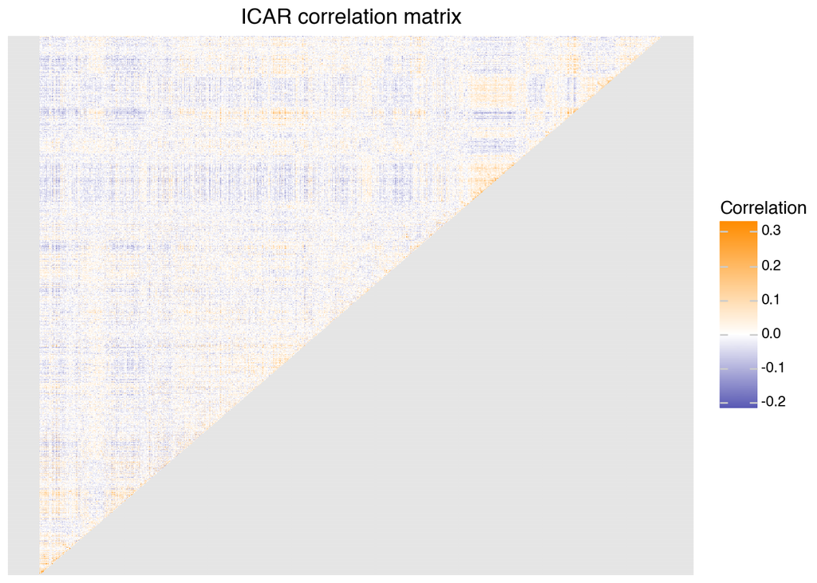

```python
phi_icar = pois_icar_fit.stan_variable("phi")
corr_plot = plot_icar_corr_matrix(phi_icar, 'ICAR correlation matrix', (10, 10))
corr_plot
```

**R**

````markdown
```{r}
phi_icar <- as_draws_matrix(pois_icar_fit$draws("phi"))
plot_icar_corr_matrix(phi_icar, 'ICAR correlation matrix')
```
````

The correlation matrix shows strong correlation between neighbors, along the diagonal, and low correlation between distant regions, in the upper left-hand corner.

### Posterior predictive checks

**Python**

```
y total: 745, ct y is within y_rep central 50% interval: 695, pct: 93.28859060402685
```

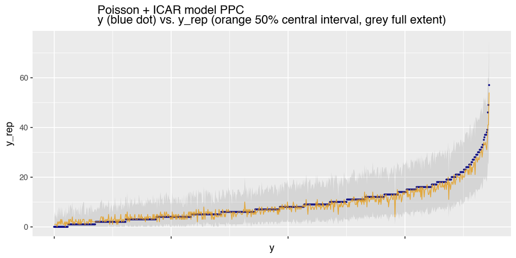

```python
y_rep_icar = pois_icar_fit.stan_variable("y_rep")
print(ppc_central_interval(y_rep_icar, pois_icar_data['y']))

ppc_plot = ppc_y_yrep_overlay(y_rep_icar, pois_icar_data['y'],
                                'Poisson + ICAR model PPC\ny (blue dot) vs. y_rep (orange 50% central interval, grey full extent)')
ppc_plot
```

**R**

````markdown
```{r}
y_rep_icar <- as_draws_matrix(pois_icar_fit$draws("y_rep"))
ppc_central_interval(y_rep_icar, pois_icar_data$y)
ppc_y_yrep_overlay(y_rep_icar, pois_icar_data$y,
                     'Poisson + ICAR model PPC\ny (blue dot) vs. y_rep (orange 50% central interval, grey full extent)')
```
````

## Model Comparison: Poisson + ICAR vs. Poisson vs. Poisson + RE

The Poisson-ICAR model falls into the category of “non-factorized models”, for which simple leave-one-out cross-validation fails to hold, due to the fact that observations depend on other observations from different spatial units in addition to the dependence on the model parameters Doing cross-validation would require recoding the model, and then re-fitting is $N$ times, once per omitted observation. Therefore, we compare summary statistics, visualizations, and model runtimes.

#### Poisson model (with centered predictors)

**Python**

```python
pois_mod = CmdStanModel(stan_file=os.path.join('..', 'stan', 'poisson_ctr_preds.stan'))
pois_fit = pois_mod.sample(data=pois_icar_data)
pois_fit.summary().round(2).loc[
  ['beta_intercept', 'beta0', 'betas[1]', 'betas[2]', 'betas[3]', 'betas[4]']]
```

```
09:40:49 - cmdstanpy - INFO - CmdStan start processing
```

```
09:40:49 - cmdstanpy - INFO - CmdStan done processing.
```

|  | Mean | MCSE | StdDev | MAD | 5% | 50% | 95% | ESS_bulk | ESS_tail | R_hat |
| --- | --- | --- | --- | --- | --- | --- | --- | --- | --- | --- |
| beta_intercept | -6.81 | 0.01 | 0.35 | 0.35 | -7.39 | -6.81 | -6.22 | 4318.36 | 3351.31 | 1.0 |
| beta0 | -4.12 | 0.00 | 0.01 | 0.01 | -4.14 | -4.12 | -4.10 | 4194.23 | 3128.22 | 1.0 |
| betas[1] | 0.64 | 0.00 | 0.13 | 0.13 | 0.43 | 0.64 | 0.85 | 3004.98 | 2893.66 | 1.0 |
| betas[2] | 0.12 | 0.00 | 0.03 | 0.03 | 0.07 | 0.12 | 0.17 | 4440.03 | 3241.03 | 1.0 |
| betas[3] | 0.09 | 0.00 | 0.02 | 0.02 | 0.07 | 0.09 | 0.12 | 4755.46 | 3078.41 | 1.0 |
| betas[4] | 0.06 | 0.00 | 0.01 | 0.01 | 0.05 | 0.06 | 0.08 | 3470.09 | 2743.06 | 1.0 |

**R**

````markdown
```{r}
pois_re_mod = cmdstan_model(stan_file=file.path('..', 'stan', 'poisson_ctr_preds.stan'))
pois_re_fit = pois_re_mod$sample(data=pois_icar_data, parallel_chains=cores, refresh=0)
pois_re_fit
```
````

#### Poisson + RE model

**Python**

```python
pois_re_mod = CmdStanModel(stan_file=os.path.join('..', 'stan', 'poisson_re.stan'))
pois_re_fit = pois_re_mod.sample(data=pois_icar_data)
pois_re_fit.summary().round(2).loc[
  ['beta_intercept', 'beta0', 'betas[1]', 'betas[2]', 'betas[3]', 'betas[4]', 'sigma']]
```

```
09:40:53 - cmdstanpy - INFO - CmdStan start processing
```

```
09:40:55 - cmdstanpy - INFO - CmdStan done processing.
```

|  | Mean | MCSE | StdDev | MAD | 5% | 50% | 95% | ESS_bulk | ESS_tail | R_hat |
| --- | --- | --- | --- | --- | --- | --- | --- | --- | --- | --- |
| beta_intercept | -6.50 | 0.03 | 0.81 | 0.80 | -7.84 | -6.50 | -5.14 | 897.62 | 1418.17 | 1.00 |
| beta0 | -4.26 | 0.00 | 0.03 | 0.03 | -4.30 | -4.26 | -4.21 | 874.18 | 1542.71 | 1.00 |
| betas[1] | 0.76 | 0.01 | 0.27 | 0.27 | 0.30 | 0.76 | 1.20 | 898.08 | 1836.85 | 1.00 |
| betas[2] | 0.08 | 0.00 | 0.07 | 0.07 | -0.03 | 0.08 | 0.19 | 820.00 | 1428.22 | 1.00 |
| betas[3] | 0.08 | 0.00 | 0.04 | 0.04 | 0.03 | 0.08 | 0.14 | 774.54 | 1164.79 | 1.01 |
| betas[4] | 0.05 | 0.00 | 0.02 | 0.02 | 0.02 | 0.05 | 0.09 | 706.25 | 1511.35 | 1.00 |
| sigma | 0.67 | 0.00 | 0.02 | 0.02 | 0.63 | 0.67 | 0.71 | 982.01 | 1990.18 | 1.00 |

**R**

````markdown
```{r}
pois_re_mod = cmdstan_model(stan_file=file.path('..', 'stan', 'poisson_re.stan'))
pois_re_fit = pois_re_mod$sample(data=pois_icar_data, parallel_chains=cores, refresh=0)
pois_re_fit
```
````

### Compare Posterior predictive check coverage

**Python**

```python
print(ppc_central_interval(y_rep_icar, pois_icar_data['y']))

y_rep_pois = pois_fit.stan_variable("y_rep")
print(ppc_central_interval(y_rep_pois, pois_icar_data['y']))

y_rep_re = pois_re_fit.stan_variable("y_rep")
print(ppc_central_interval(y_rep_re, pois_icar_data['y']))
```

```
y total: 745, ct y is within y_rep central 50% interval: 695, pct: 93.28859060402685
y total: 745, ct y is within y_rep central 50% interval: 251, pct: 33.691275167785236
y total: 745, ct y is within y_rep central 50% interval: 719, pct: 96.51006711409396
```

**R**

````markdown
```{r}
y_rep_icar <- as_draws_matrix(pois_icar_fit$draws("y_rep"))
ppc_central_interval(y_rep_icar, pois_icar_data$y)

y_rep_pois <- as_draws_matrix(pois_re_fit$draws("y_rep"))
ppc_central_interval(y_rep_pois, pois_icar_data$y)

y_rep_re <- as_draws_matrix(pois_re_fit$draws("y_rep"))
ppc_central_interval(y_rep_re, pois_icar_data$y)
```
````

### Poisson Model PPC plots

**Python**

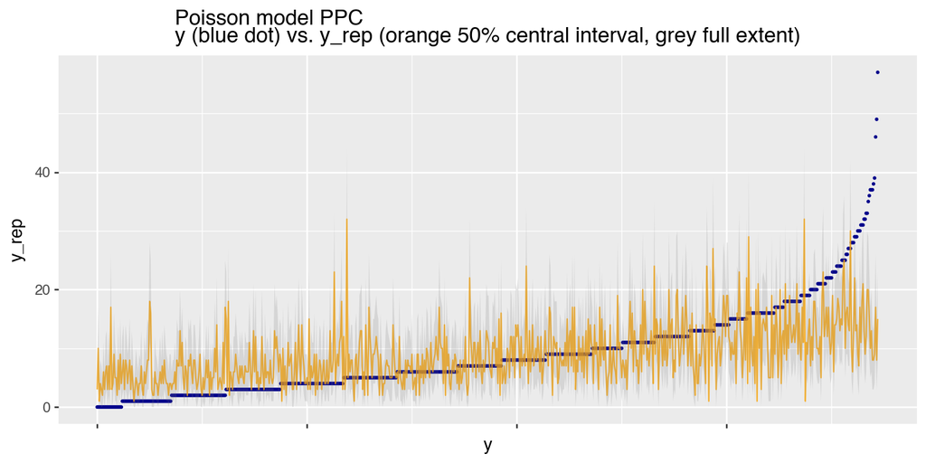

```python
ppc_plot = ppc_y_yrep_overlay(y_rep_pois, pois_icar_data['y'],
                                'Poisson model PPC\ny (blue dot) vs. y_rep (orange 50% central interval, grey full extent)')
ppc_plot
```

**R**

````markdown
```{r}
ppc_y_yrep_overlay(y_rep_pois, pois_icar_data$y,
                     'Poisson model PPC\ny (blue dot) vs. y_rep (orange 50% central interval, grey full extent)')
```
````

### Poisson + RE Model PPC plots

**Python**

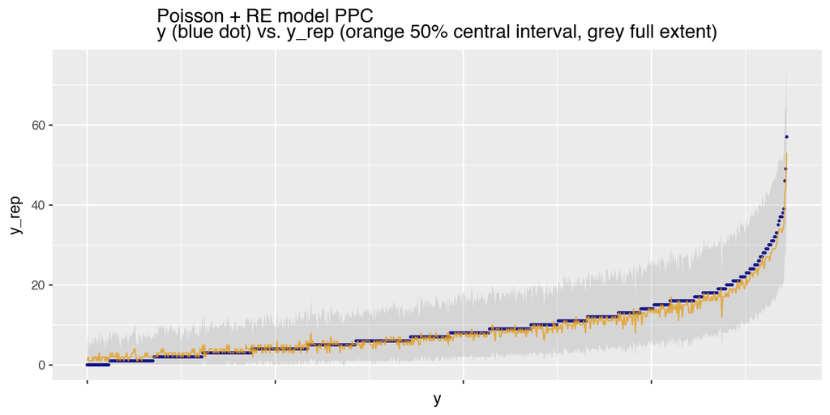

```python
ppc_plot = ppc_y_yrep_overlay(y_rep_re, pois_icar_data['y'],
                                'Poisson + RE model PPC\ny (blue dot) vs. y_rep (orange 50% central interval, grey full extent)')
ppc_plot
```

**R**

````markdown
```{r}
ppc_y_yrep_overlay(y_rep_re, pois_icar_data$y,
                     'Poisson + RE model PPC\ny (blue dot) vs. y_rep (orange 50% central interval, grey full extent)')
```
````

### Poisson + ICAR Model PPC plots

**Python**

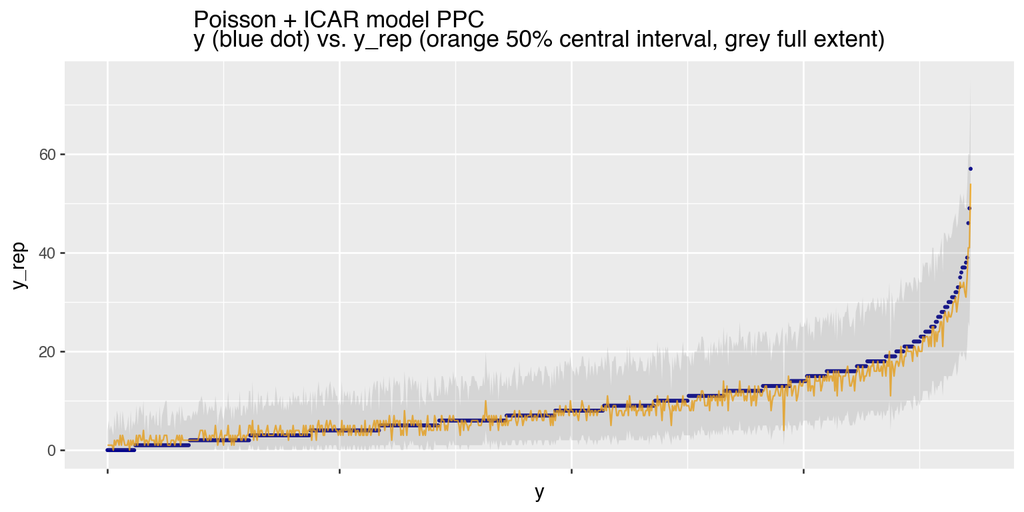

```python
ppc_plot = ppc_y_yrep_overlay(y_rep_icar, pois_icar_data['y'],
                                'Poisson + ICAR model PPC\ny (blue dot) vs. y_rep (orange 50% central interval, grey full extent)')
ppc_plot
```

**R**

````markdown
```{r}
ppc_y_yrep_overlay(y_rep_icar, pois_icar_data$y,
                     'Poisson + ICAR model PPC\ny (blue dot) vs. y_rep (orange 50% central interval, grey full extent)')
```
````

## Discussion

The Poisson + RE model has somewhat better predictive coverage because the random effects component `theta` effectively accounts for the overdispersed nature of the data. However, visualization of the ICAR component demonstrates that the ICAR component does a good job of capturing the spatial structure of the data and also provides good predictive performance. In the next notebook, we show how to combine both components into the BYM2 model.